# Multilevel Modelling – Practical 2 (Week 3)

## Instructions – start here!

The first part of this notebook (**Exercise 1**) reproduces the images displayed through the use of `ggplot` in Lecture 3 of this module. The code in this example is influenced by https://www.rensvandeschoot.com/tutorials/lme4/.

The second part of the notebook (**Exercise 2**) allows you to test your `ggplot2` skills. If time permits, you may apply ggplot2 more freely onto another data set (**Exercise 3**).

We initially load two useful R packages (*haven*, *ggplot2*).

```r
# ---------------------------------------------------------------------
# clear the environment var area
rm(list = ls())
# clear all plots
graphics.off()
# clear the console area
cat("\014")
```

```r
# ---------------------------------------------------------------------
```

```r
#You may need to install these packages!
require(haven)      # to load the SPSS .sav file
require(ggplot2)    # used for production of graphs
```

If you don’t have the above packages, you will need to use the usual `install.packages()` and `library()` for both.

## Exercises 1

### Acquire and prepare data

Use the code below to reproduce the images from the lecture. Please do not just click your way through: try to understand and appreciate what the code does in all instances, and try to execute minor modifications of the code to observe the effect.

The following command is reading the data in directly from Andy’s Github page.

```r
pop.rawdata <-
  read_sav(file = "https://andygolightly.github.io/teaching/MATH43515/popular2.sav")
```

$~$

We extract the relevant columns, relabel accordingly, and display the first six rows.

```r
pop.data <-
  pop.rawdata[, c("pupil", "class", "extrav", "sex", "texp", "popular")]

colnames(pop.data) <-
  c("pupil",
    "class",
    "extraversion",
    "gender",
    "experience",
    "popularity")

head(pop.data) # we have a look at the first 6 observations
```

| pupil | class | extraversion | gender | experience | popularity |
| --- | --- | --- | --- | --- | --- |
| 1 | 1 | 5 | 1 | 24 | 6.3 |
| 2 | 1 | 7 | 0 | 24 | 4.9 |
| 3 | 1 | 4 | 1 | 24 | 5.3 |
| 4 | 1 | 3 | 1 | 24 | 4.7 |
| 5 | 1 | 5 | 1 | 24 | 6.0 |
| 6 | 1 | 4 | 0 | 24 | 4.7 |

The following creates some auxiliary data frames, purely for visualization purpopses.

```r
Ex <- data.frame(table(pop.data$extraversion))
colnames(Ex) <- c("extraversion", "frequency")

Gen <- data.frame(table(pop.data$gender))
colnames(Gen) <-  c("gender", "frequency")

Tex <- data.frame(table(pop.data$experience))
colnames(Tex) <- c("experience", "frequency")
```

### Exploratory analysis

Produce a histogram of the response variable.

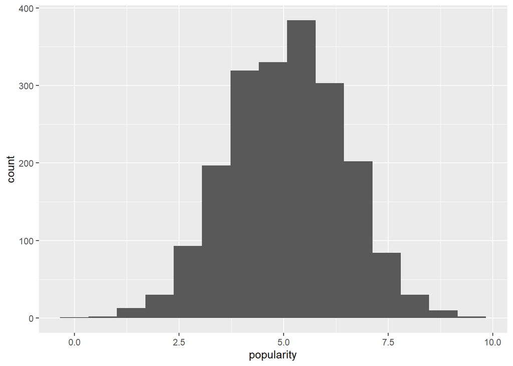

```r
ggplot(data = pop.data, aes(popularity)) +
  geom_histogram(bins = 15)
```

**TASK**: Try `col="black", fill="light blue"` inside `geom_histogram()`.

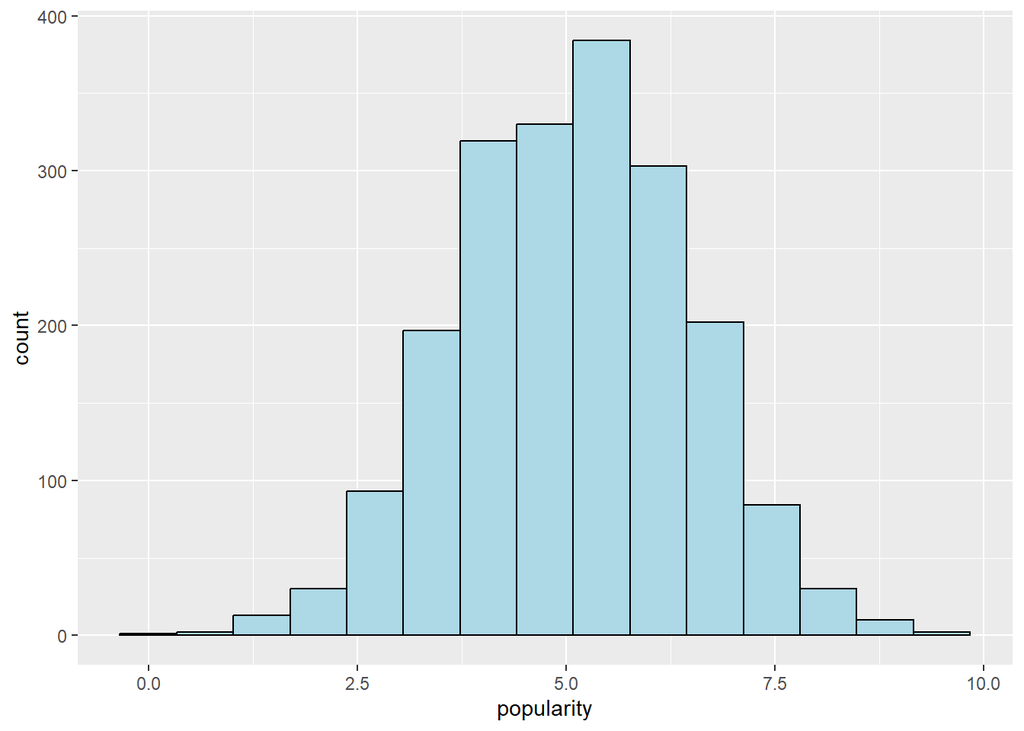

```r
ggplot(data = pop.data, aes(popularity)) +
  geom_histogram(bins = 15, col="black", fill="light blue")
```

Visualise the explanatory variables as follows.

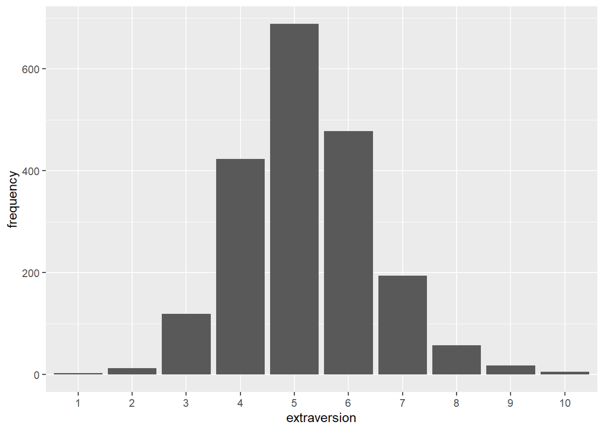

```r
ggplot(data=Ex, aes(x=extraversion, y=frequency)) +
   geom_bar(stat="identity")
```

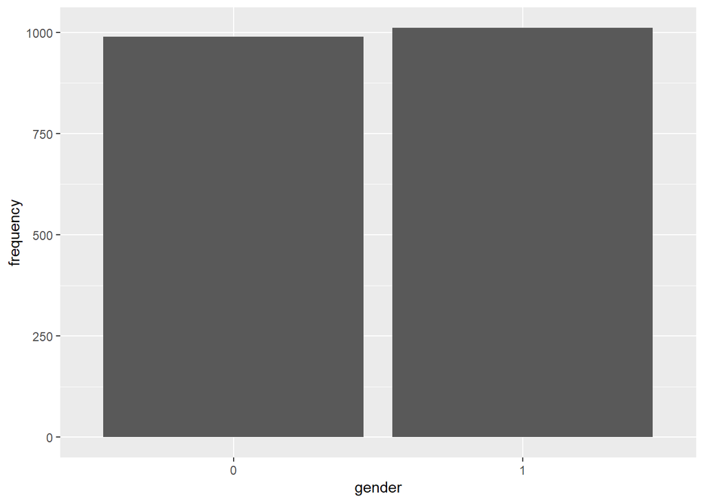

```r
ggplot(data=Gen, aes(x=gender, y=frequency)) +
   geom_bar(stat="identity")
```

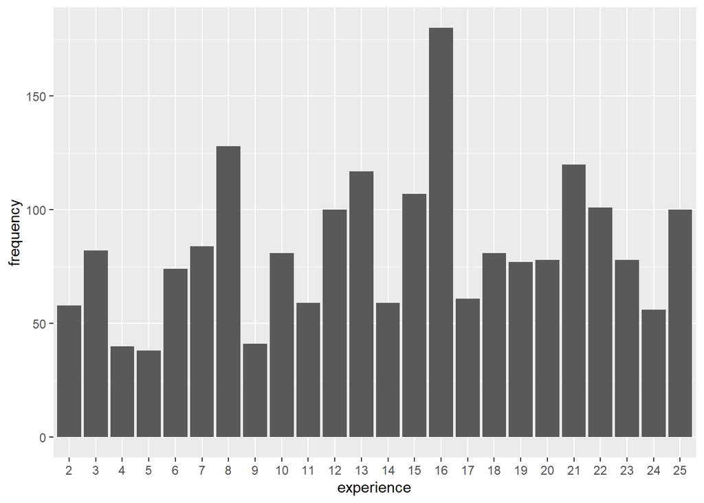

```r
ggplot(data=Tex, aes(x=experience, y=frequency)) +
  geom_bar(stat="identity")
```

**TASK**: What does `stat="identity"` do? Check the help file via `?geom_bar`.

> **stat=“identity”**: The `stat` parameter within `geom_bar` specifies the statistical transformation to use on the data for this layer. By default, `geom_bar` uses `stat="count"`, which makes the height of the bar proportional to the number of cases in each category (or group). When you use `stat="identity"`, you’re telling `ggplot2` to use the actual values in your data for the heights of the bars. This is commonly used when you already have summarized data, where each row of your data frame represents counts, or some other value that you want to display directly.

Scatterplot of popularity against extraversion and Pearson correlation:

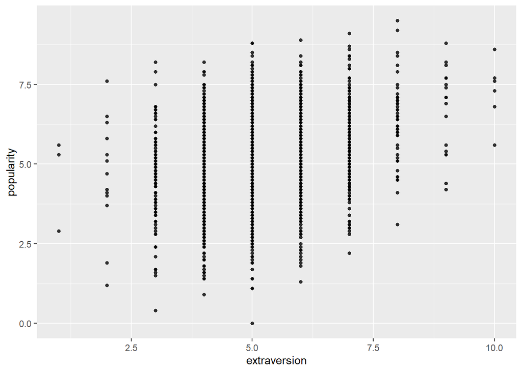

```r
ggplot(data = pop.data, aes(x = extraversion, y = popularity)) +
  geom_point(size = 1.2, alpha = .8)
```

```r
cor(pop.data$extraversion, pop.data$popularity)
```

```
## [1] 0.3157935
```

**TASK**: What does `size` and `alpha` do in `geom_point()`?

$~$

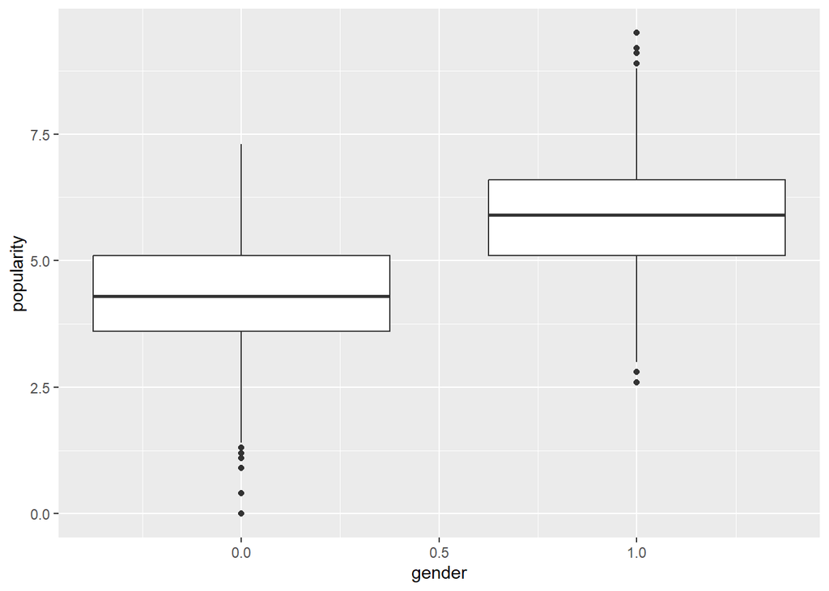

```r
ggplot(data  = pop.data, aes(x = gender, y = popularity, group = gender)) +
  geom_boxplot()
```

```r
cor(pop.data$gender, pop.data$popularity)
```

```
## [1] 0.5682754
```

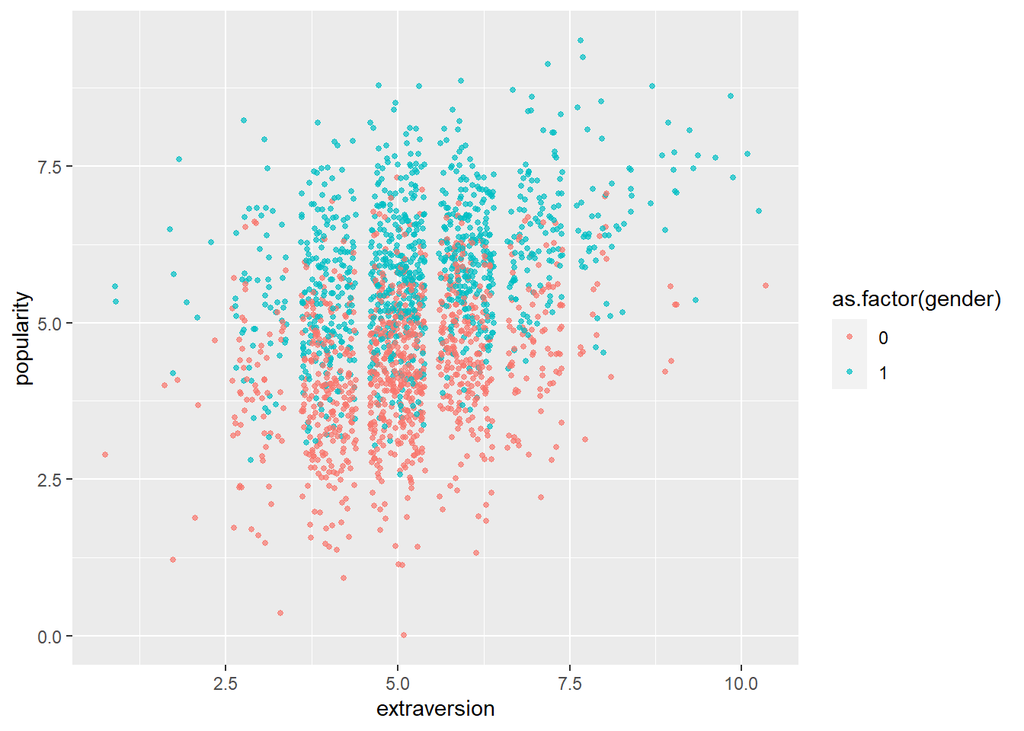

```r
ggplot(data = pop.data,
       aes(
         x   = extraversion,
         y = popularity,
         colour = as.factor(gender)
       )) +
  geom_point(size = 1,
             alpha = .7,
             position = "jitter")
```

Let’s calculate the mean popularity and mean teacher experience score within each class and store in a data frame. Although no actual averaging takes place when calculating the teacher experience means, the code is useful for the extraction of the class level variable.

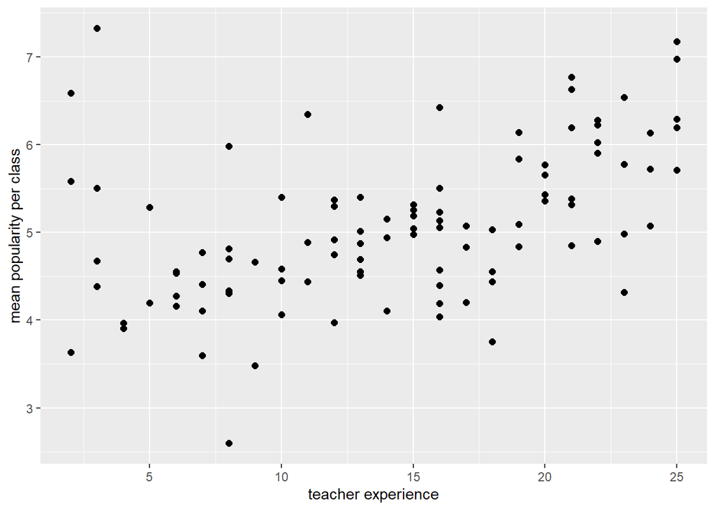

```r
pop.means <- tapply(pop.data$popularity, pop.data$class, mean)
# average popularity per class
exp.means <- tapply(pop.data$experience, pop.data$class, mean)
# extracting the upper-level variable teaching experience
# (no actual averaging takes place here, as experience is constant within classes)
class.level <- data.frame(pop.means = pop.means, exp.means = exp.means)

# Plot mean popularity per class against teacher experience
ggplot(data = class.level, aes(x = exp.means, y = pop.means)) +
  geom_point(size = 2) +
  labs(y = "mean popularity per class") +
  labs(x = "teacher experience")
```

**Task**: make clear to yourself the use of `tapply()` here.

$~$

### Naive simple linear regression models

Let’s fit a single regression model to all data. The model takes the form
$$y_{ij}=a + b x_{ij}+ \epsilon_{ij}, \quad \epsilon_{ij}\sim
N(0,\sigma^2), \quad i=1,\ldots,n_j,\quad j=1,\ldots,100.$$
We fit the model and extract estimates of $a$ and $b$ as follows.

```r
simple.linear.model <- lm(popularity ~ extraversion, data = pop.data)
summary(simple.linear.model)$coef
```

```
##               Estimate Std. Error  t value      Pr(>|t|)
## (Intercept)  3.2728356 0.12473523 26.23826 1.237371e-130
## extraversion 0.3458513 0.02324748 14.87694  1.481801e-47
```

```r
a <- simple.linear.model$coef[1]
b <- simple.linear.model$coef[2]
```

Plot the data and overlay the fitted regression line:

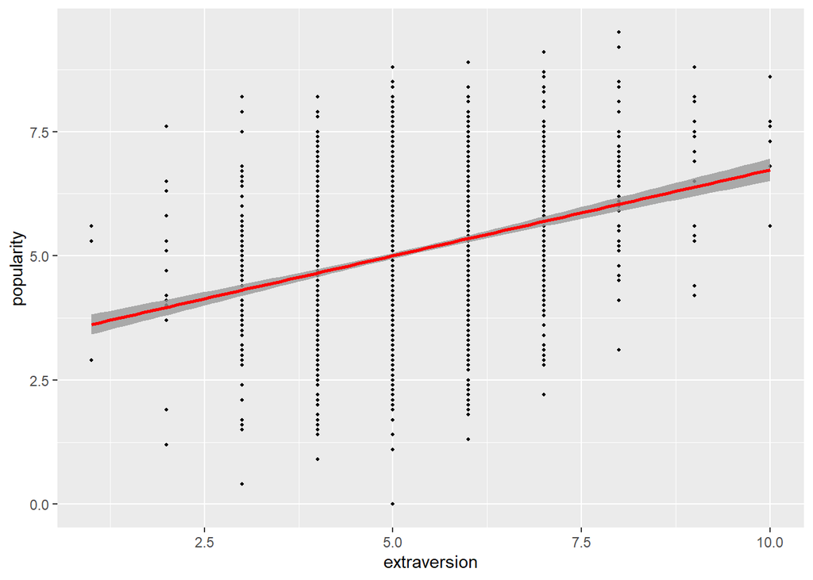

```r
ggplot(data  = pop.data, aes(x = extraversion, y = popularity)) +
  geom_point(size = 0.7) +
  geom_smooth(
    method = lm,
    # to add regression line
    se = TRUE,
    col = "red",
    size = 1,
    alpha = .8
  )
```

Let’s produce a scatterplot with jitter, colour by class:

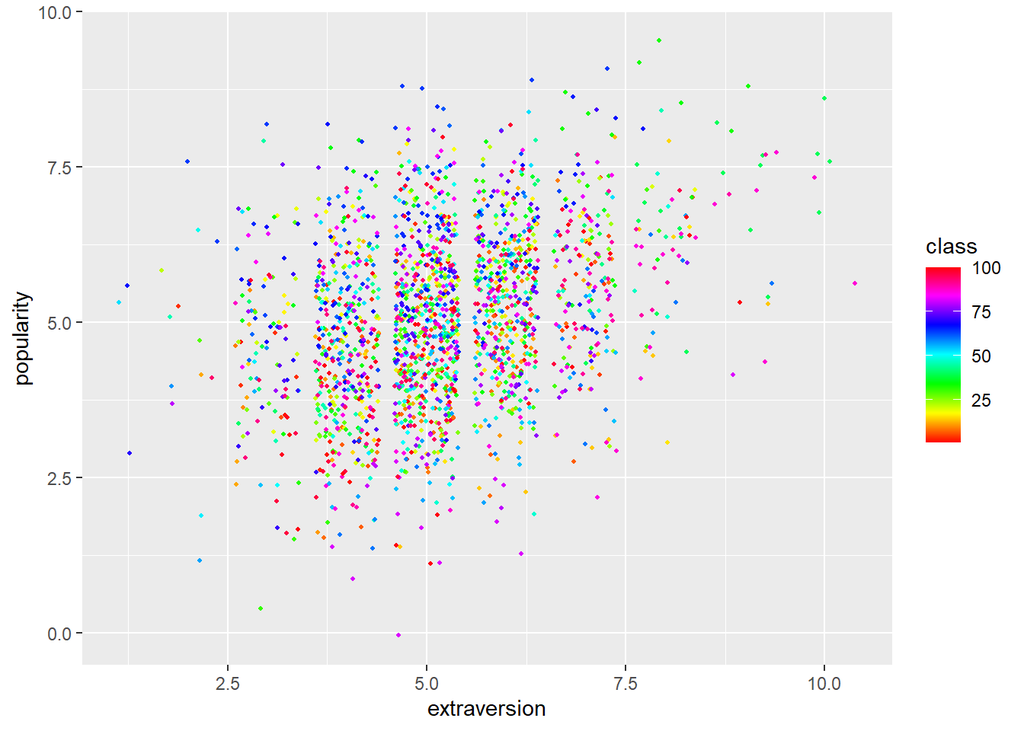

```r
ggplot(data  = pop.data, aes(x = extraversion, y = popularity, col = class)) +
  geom_jitter(size = 0.8) +  # to add some random noise for plotting purposes
  scale_color_gradientn(colours = rainbow(100)) # +
```

Does one line fit all? We now fit a separate model for each class. The models take the form (for each class $j$)
$$y_{ij}=a_j+b_j x_{ij}+\epsilon_{ij}, \quad \epsilon_{ij}\sim
N(0,\sigma^2_j).$$

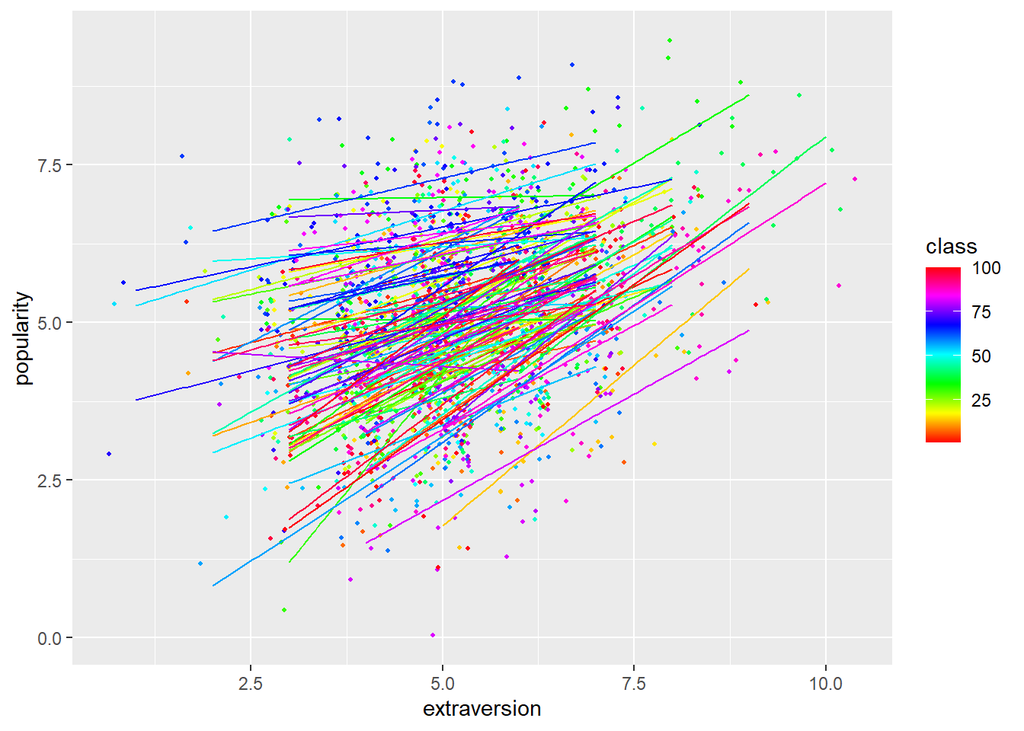

```r
ggplot(data = pop.data,
       aes(
         x = extraversion,
         y = popularity,
         colour = class,
         group = class
       )) +
  geom_jitter(size = 0.8) +
  geom_smooth(
    method = lm,
    se = FALSE,
    size = .5,
    alpha  = .8
  ) +
  scale_color_gradientn(colours = rainbow(100))
```

We can extract the estimates of $a_j$ and $b_j$ via a `for` loop:

```r
fit.all <-
  matrix(NA, 100, 2) #one row for each class, cols are a and b
for (j in 1:100) {
  #loop over classes
  fit.all[j, ] <-
    lm(popularity ~ extraversion,
       data = pop.data,
       subset = pop.data$class == j)$coef
}
colnames(fit.all) <- c("intercept", "slope")
fit.all <- as.data.frame(fit.all)
```

Finally, plot histograms of the $a_j$ and $b_j$ estimates:

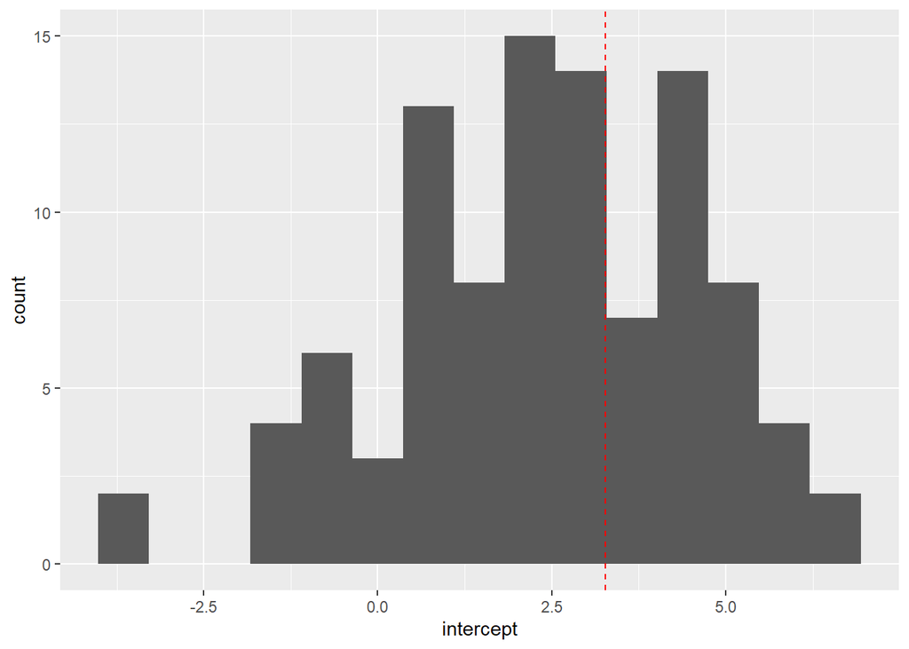

```r
ggplot(data=fit.all, aes(intercept)) +
  geom_histogram(bins=15) + geom_vline(xintercept=a, linetype="dashed", color = "red")
```

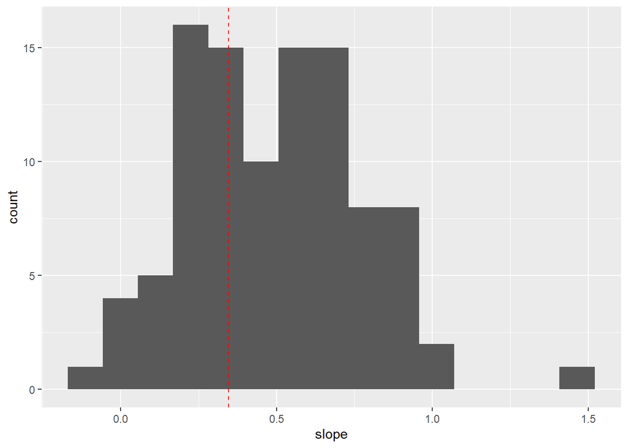

```r
ggplot(data=fit.all, aes(slope)) +
  geom_histogram(bins=15) + geom_vline(xintercept=b, linetype="dashed", color = "red")
```

**TASK** (harder): suppose that we model the intercepts via $a_j = a +u_{j}$ where $u_j\sim N(0,\sigma^2_u)$ independently of all other random variables. Write down the resulting model in the form $y_{ij}= \ldots$. Is this likely to be a sensible model? What exploratory techniques can we use to answer his question? Discuss with colleagues and/or Andy.

For two pupils in the same class, what is the covariance between response values? What is the covariance between the response values of two pupils from different classes? How might we model the $b_j$?

(Don’t worry if this looks a bit odd - we will unpack in next week’s lecture!)

$~$